# FIT3181: Deep Learning (2021)

*CE/Lecturer:* Dr **Trung Le** | trunglm@monash.edu  
*Head Tutor:* Mr **Thanh Nguyen** | thanh.nguyen4@monash.edu  
Department of Data Science and AI, Faculty of Information Technology, Monash University, Australia

# Student Information

Surname: **Haw**  
Firstname: **Xiao Ying**  
Student ID: **29797918**  
Email: **xhaw0001@student.monash.edu**  
Your tutorial time: **Tuesday 3.00p.m.-5.00p.m.**

## Part 3: Convolutional Neural Networks and Image Classification

[Total marks for this part: 40 points]

**This part of the asssignment is designed to access your knowledge and coding skill with Tensorflow as well as hands-on experience with training Convolutional Neural Network (CNN).**

**The dataset we use for this part is a small animal dataset consisting of $5,000$ images of cats, dogs, fishes, lions, chickens, elephants, butterflies, cows, spiders, and horses, each of which has 500 images. You can download the dataset at [download here](https://drive.google.com/file/d/1bEwEx72lLrjY_Idj_FgV22atIdjtCV66/view?usp=sharing) and then decompress to the folder the folder `datasets\Animals` for you in the assignment folder.**

**Your task is to build a CNN model using *TF 2.x* to classify these animals. You're provided with the module models.py, which you can find in the assignment folder, with some of the following classes:**

1. `AnimalsDatasetManager`: Support with loading and spliting the dataset into the train-val-test sets. It also help generate next batches for training. `AnimalsDatasetManager` will be passed to CNN model for training and testing.
2. `Layers`: A class providing some static method to create basic CNN layers.
3. `DefaultModel`: A base class for the CNN model.
4. `YourModel`: The class you'll need to implement to build the CNN model. It inherits some useful attributes and functions from the base class `DefaultModel`

Firstly, we need to run the following cells to load and preprocess the Animal dataset.

```python
%load_ext autoreload
%autoreload 2
```

```python
import os
import matplotlib.pyplot as plt
plt.style.use('ggplot')
%matplotlib inline
import models
from models import SimplePreprocessor, AnimalsDatasetManager, DefaultModel
```

```python
def create_label_folder_dict(adir):
    sub_folders= [folder for folder in os.listdir(adir)
                  if os.path.isdir(os.path.join(adir, folder))]
    label_folder_dict= dict()
    for folder in sub_folders:
        item= {folder: os.path.abspath(os.path.join(adir, folder))}
        label_folder_dict.update(item)
    return label_folder_dict
```

```python
label_folder_dict= create_label_folder_dict("./datasets/Animals")
```

The below code helps to create a data manager that contains all relevant methods used to manage and process our experimental data.

```python
sp = SimplePreprocessor(width=32, height=32)
data_manager = AnimalsDatasetManager([sp])
data_manager.load(label_folder_dict, verbose=100)
data_manager.process_data_label()
data_manager.train_valid_test_split()
```

```
butterfiles 500
Processed 100/500
Processed 200/500
Processed 300/500
Processed 400/500
Processed 500/500
cats 501
Processed 100/500
Processed 200/500
Processed 300/500
Processed 400/500
Processed 500/500
chickens 500
Processed 100/500
Processed 200/500
Processed 300/500
Processed 400/500
Processed 500/500
cows 500
Processed 100/500
Processed 200/500
Processed 300/500
Processed 400/500
Processed 500/500
dogs 501
Processed 100/500
Processed 200/500
Processed 300/500
Processed 400/500
Processed 500/500
elephants 500
Processed 100/500
Processed 200/500
Processed 300/500
Processed 400/500
Processed 500/500
fishes 500
Processed 100/500
Processed 200/500
Processed 300/500
Processed 400/500
Processed 500/500
horses 500
Processed 100/500
Processed 200/500
Processed 300/500
Processed 400/500
Processed 500/500
lions 500
Processed 100/500
Processed 200/500
Processed 300/500
Processed 400/500
Processed 500/500
spiders 500
Processed 100/500
Processed 200/500
Processed 300/500
Processed 400/500
Processed 500/500
```

Note that the object `data_manager` has the attributes relating to *the training, validation, and testing sets* as shown belows. You can use them in training your developped models in the sequel.

```python
print(data_manager.X_train.shape, data_manager.y_train.shape)
print(data_manager.X_valid.shape, data_manager.y_valid.shape)
print(data_manager.X_test.shape, data_manager.y_test.shape)
print(data_manager.classes)
```

```
(4000, 32, 32, 3) (4000,)
(500, 32, 32, 3) (500,)
(500, 32, 32, 3) (500,)
['butterfiles' 'cats' 'chickens' 'cows' 'dogs' 'elephants' 'fishes'
 'horses' 'lions' 'spiders']
```

We now run the **default model** built in the **models.py** file which serves as a basic baseline to start the investigation. Follow the following steps to realize how to run a model and know the built-in methods associated to a model developped in the DefaultModel class.

We first initialize a default model from the DefaultModel class. Basically, we can define the relevant parameters of training a model including `num_classes`, `optimizer`, `learning_rate`, `batch_size`, and `num_epochs`.

```python
network1 = DefaultModel(name='network1',
                       num_classes=len(data_manager.classes),
                       optimizer='sgd',
                       batch_size= 128,
                       num_epochs = 20,
                       learning_rate=0.5)
```

The method `build_cnn()` assists us in building your convolutional neural network. You can view the code (in the **models.py** file) of the model behind a default model to realize how simple it is. Additionally, the method `summary()` shows the architecture of a model.

```python
network1.build_cnn()
network1.summary()
```

```
Model: "sequential_1"
_________________________________________________________________
Layer (type)                 Output Shape              Param #
=================================================================
conv2d (Conv2D)              (None, 32, 32, 32)        896
_________________________________________________________________
conv2d_1 (Conv2D)            (None, 32, 32, 32)        9248
_________________________________________________________________
average_pooling2d (AveragePo (None, 16, 16, 32)        0
_________________________________________________________________
conv2d_2 (Conv2D)            (None, 16, 16, 64)        18496
_________________________________________________________________
conv2d_3 (Conv2D)            (None, 16, 16, 64)        36928
_________________________________________________________________
average_pooling2d_1 (Average (None, 8, 8, 64)          0
_________________________________________________________________
flatten (Flatten)            (None, 4096)              0
_________________________________________________________________
dense (Dense)                (None, 10)                40970
=================================================================
Total params: 106,538
Trainable params: 106,538
Non-trainable params: 0
_________________________________________________________________
None
```

To train a model regarding to the datasets stored in `data_manager`, you can invoke the method `fit()` for which you can specify the batch size and number of epochs for your training.

```python
network1.fit(data_manager, batch_size = 64, num_epochs = 20)
```

Here you can compute the accuracy of your trained model with respect to a separate testing set.

```python
network1.compute_accuracy(data_manager.X_test, data_manager.y_test)
```

```
0.08399999886751175
```

Below shows how you can inspect the training progress.

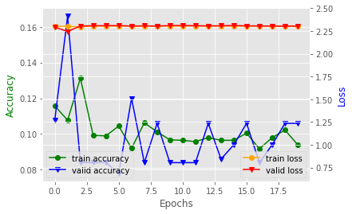

```python
network1.plot_progress()
```

You can use the method `predict()` to predict labels for data examples in a test set.

```python
network1.predict(data_manager.X_test[0:10])
```

```
array([3, 3, 3, 3, 3, 3, 3, 3, 3, 3], dtype=int64)
```

Finally, the method `plot_prediction()` visualizes the predictions for a test set in which several images are chosen to show the predictions.

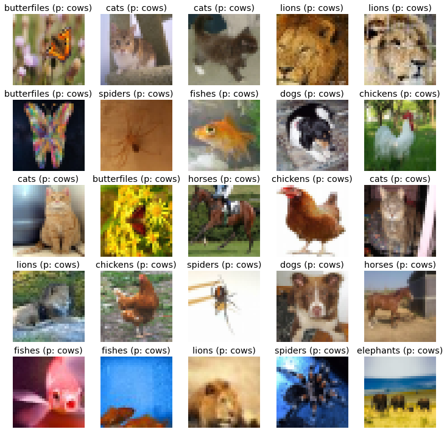

```python
network1.plot_prediction(data_manager.X_test, data_manager.y_test, data_manager.classes)
```

**Question 3.1** **After running the above cells to train the default model and observe the learning curve. Report your observation (i.e. did the model learn well? if not, what is the problem? what would you do to improve it?). Write your answer below.**

[4 points]

**Answer for Question 3.1**  
*The model did not learn well. The accuracy of this model is only around 8%, which is too low. The loss, train loss and validation loss is also high. Besides that, looking at the graph (learning curve) above, the validation accuracy is fluctuating, which is just like random guessing. Maybe the problem is because the model did not implement batch normalization and droupout. To improve, we can modify the model so that it uses the BatchNormalization function and also add Dropout function to the model. We can also reduce the learning rate to 0.001 rather than using 0.5 to enhance the performance of the model. Data augmentation, label smoothing and data mixup technique can also be used to improve the model.*

**For question 3.2 to 3.6, you'll need to write your own model in a way that makes it easy for you to experiment with different architectures as well as parameters. The goal is to be able to pass the parameters to initialize a new instance of `YourModel` to build different network architectures with different parameters. Below are descriptions of some parameters for `YourModel`, which you can find in function `__init__()` for the class `DefaultModel`:**

1. `num_blocks`: an integer specifying the number of blocks in our network. Each block has the pattern `[conv, batch norm, activation, conv, batch norm, activation, mean pool, dropout]`. All convolutional layers have filter size $(3, 3)$, strides $(1, 1)$ and 'SAME' padding, and all mean pool layers have strides $(2, 2)$ and 'SAME' padding. The network will consists of a few blocks before applying a linear layer to output the logits for the softmax layer.
2. `feature_maps`: the number of feature maps in the first block of the network. The number of feature_maps will double in each of the following block. To make it convenient for you, we already calculated the number of feature maps for each block for you in line $106$
3. `drop_rate`: the keep probability for dropout. Setting `drop_rate` to $0.0$ means not using dropout.
4. `batch_norm`: the batch normalization function is used or not. Setting `batch_norm` to `None` means not using batch normalization.

```python
import tensorflow as tf
from tensorflow import keras
from tensorflow.keras import layers, models
from tensorflow.keras.models import Sequential
from tensorflow.keras.layers import Dense, Flatten
from tensorflow.keras import models, layers
from tensorflow.keras.layers import Dense, BatchNormalization, Conv2D, MaxPooling2D, Dropout
```

**Question 3.2** **Write the code of the `YourModel` class here. Note that this class will inherit from the `DefaultModel` class. You'll only need to re-write the code for the `build_cnn` method for the `YourModel` class from the cell below which is inherited from the `DefaultModel` class.**

[4 points]

```python
class YourModel(DefaultModel):
    def __init__(self,
                 name='network1',
                 width=32, height=32, depth=3,
                 num_blocks=2,
                 feature_maps=32,
                 num_classes=4,
                 drop_rate=0.2,
                 batch_norm = None,
                 is_augmentation = False,
                 activation_func='relu',
                 optimizer='adam',
                 batch_size=10,
                 num_epochs= 20,
                 learning_rate=0.0001,
                 verbose= True):
        super(YourModel, self).__init__(name, width, height, depth, num_blocks, feature_maps, num_classes, drop_rate,
                                        batch_norm, is_augmentation, activation_func, optimizer, batch_size, num_epochs,
                                        learning_rate, verbose)

    def build_cnn(self):
        self.model = models.Sequential()
        self.model.add(Conv2D(32, (3,3), padding='same', activation=self.activation_func, input_shape=(32,32,3)))
        self.model.add(Conv2D(32, (3,3), padding='same', activation=self.activation_func))
        self.model.add(MaxPooling2D(pool_size=(2, 2), padding='same'))
        if self.batch_norm is not None:
            self.model.add(BatchNormalization())
        self.model.add(Dropout(self.drop_rate))

        self.model.add(Conv2D(64, (3,3), padding='same', activation=self.activation_func))
        self.model.add(Conv2D(64, (3,3), padding='same', activation=self.activation_func))
        self.model.add(MaxPooling2D(pool_size=(2, 2), padding='same'))
        if self.batch_norm is not None:
            self.model.add(BatchNormalization())
        self.model.add(Dropout(self.drop_rate))

        self.model.add(Flatten())
        self.model.add(Dense(self.num_classes, activation='softmax'))
        self.model.compile(optimizer=self.optimizer, loss='sparse_categorical_crossentropy', metrics=['accuracy'])
```

**Question 3.3** **Once writing your own models, you should be able to use it to experiment with dropout or batch normalization. In this question, you'll use your model to finetune the dropout rate. Report the `drop_rate` rates you tried along with the validation accuracy for each rate (recomended range: 0.2 to 0.5) and show the losses during training. What is the final `drop_rate` rate that you'll use? Did dropout improve performance? Did it help reduce overfitting? Note that in this experiment, you should set `batch_norm` to `None`, meaning that we do not use the batch normalization.**

[4 points]

Finetune the dropout rate: 0.2, 0.3, 0.4 & 0.5

```python
drop_rate_list = [0.2, 0.3, 0.4, 0.5]
best_acc = -1
best_dr = -1
best_loss = -1

for dr in drop_rate_list:
    print("Evaluating with {} as drop out rate ...".format(dr))
    my_network = YourModel(name='network1',
                           feature_maps=32,
                           num_classes=len(data_manager.classes),
                           num_blocks=4,
                           drop_rate= dr,
                           batch_norm=None,
                           optimizer='adam',
                           learning_rate= 0.001)
    my_network.build_cnn()
    my_network.fit(data_manager, num_epochs=20)
    loss, acc = my_network.model.evaluate(data_manager.X_test, data_manager.y_test)
    if acc > best_acc:
        best_acc = acc
        best_loss = loss
        best_dr = dr
    print("Loss and accuracy for model with drop rate {} is {:.4f} and {:.4f} respectively.\n".format(dr, loss, acc))

print("Best drop out rate is {} with accuracy of {:.4f} and loss of {:.4f}.".format(best_dr, best_acc, best_loss))
```

```
Evaluating with 0.2 as drop out rate ...
Loss and accuracy for model with drop rate 0.2 is 2.1532 and 0.5800 respectively.

Evaluating with 0.3 as drop out rate ...
Loss and accuracy for model with drop rate 0.3 is 1.6924 and 0.6380 respectively.

Evaluating with 0.4 as drop out rate ...
Loss and accuracy for model with drop rate 0.4 is 1.2716 and 0.6240 respectively.

Evaluating with 0.5 as drop out rate ...
Loss and accuracy for model with drop rate 0.5 is 0.9766 and 0.6800 respectively.

Best drop out rate is 0.5 with accuracy of 0.6800 and loss of 0.9766.
```

Use the best dropout rate obtained above and apply it into the model

```python
drop_out_network = YourModel(name='network1',
                     feature_maps=32,
                     num_classes=len(data_manager.classes),
                     num_blocks=4,
                     drop_rate= 0.5,
                     batch_norm=None,
                     optimizer='adam',
                     learning_rate= 0.001)
drop_out_network.build_cnn()
drop_out_network.summary()
```

```
Model: "sequential_15"
_________________________________________________________________
Layer (type)                 Output Shape              Param #
=================================================================
conv2d_28 (Conv2D)           (None, 32, 32, 32)        896
_________________________________________________________________
conv2d_29 (Conv2D)           (None, 32, 32, 32)        9248
_________________________________________________________________
max_pooling2d_12 (MaxPooling (None, 16, 16, 32)        0
_________________________________________________________________
dropout_12 (Dropout)         (None, 16, 16, 32)        0
_________________________________________________________________
conv2d_30 (Conv2D)           (None, 16, 16, 64)        18496
_________________________________________________________________
conv2d_31 (Conv2D)           (None, 16, 16, 64)        36928
_________________________________________________________________
max_pooling2d_13 (MaxPooling (None, 8, 8, 64)          0
_________________________________________________________________
dropout_13 (Dropout)         (None, 8, 8, 64)          0
_________________________________________________________________
flatten_7 (Flatten)          (None, 4096)              0
_________________________________________________________________
dense_7 (Dense)              (None, 10)                40970
=================================================================
Total params: 106,538
Trainable params: 106,538
Non-trainable params: 0
_________________________________________________________________
None
```

```python
drop_out_network.fit(data_manager, num_epochs=20)
loss, acc = drop_out_network.model.evaluate(data_manager.X_test, data_manager.y_test)
print("Accuracy and loss of model using dropout rate = 0.3 are {} and {} respectively.".format(acc, loss))
```

[output not shown]

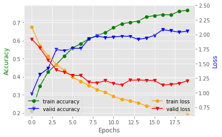

```python
drop_out_network.plot_progress()
```

**Question 3.4** **Now, let's try using batch normalization. What is the validation and test result? Does it improve the model? How does it compare to the model using dropout? To have a fair comparison, in this experiment, we set `drop_rate=0` to not use the dropout. You should show the training progress of losses and accuracies and comment about those plots. You can further comment about the efficiency of dropout and batch norm for your training.**

[4 points]

```python
batch_norm_network = YourModel(name='network4',
                     feature_maps=32,
                     num_classes=len(data_manager.classes),
                     num_blocks=4,
                     drop_rate= 0,
                     batch_norm=True, #do batch norm
                     optimizer='adam',
                     learning_rate= 0.001)
batch_norm_network.build_cnn()
batch_norm_network.summary()
```

```
Model: "sequential_17"
_________________________________________________________________
Layer (type)                 Output Shape              Param #
=================================================================
conv2d_32 (Conv2D)           (None, 32, 32, 32)        896
_________________________________________________________________
conv2d_33 (Conv2D)           (None, 32, 32, 32)        9248
_________________________________________________________________
max_pooling2d_14 (MaxPooling (None, 16, 16, 32)        0
_________________________________________________________________
batch_normalization (BatchNo (None, 16, 16, 32)        128
_________________________________________________________________
dropout_14 (Dropout)         (None, 16, 16, 32)        0
_________________________________________________________________
conv2d_34 (Conv2D)           (None, 16, 16, 64)        18496
_________________________________________________________________
conv2d_35 (Conv2D)           (None, 16, 16, 64)        36928
_________________________________________________________________
max_pooling2d_15 (MaxPooling (None, 8, 8, 64)          0
_________________________________________________________________
batch_normalization_1 (Batch (None, 8, 8, 64)          256
_________________________________________________________________
dropout_15 (Dropout)         (None, 8, 8, 64)          0
_________________________________________________________________
flatten_8 (Flatten)          (None, 4096)              0
_________________________________________________________________
dense_8 (Dense)              (None, 10)                40970
=================================================================
Total params: 106,922
Trainable params: 106,730
Non-trainable params: 192
_________________________________________________________________
None
```

```python
batch_norm_network.fit(data_manager, num_epochs=20)
loss, acc = batch_norm_network.model.evaluate(data_manager.X_test, data_manager.y_test)
print("Accuracy and loss of model using BatchNormalization are {} and {} respectively.".format(acc, loss))
```

```
Accuracy and loss of model using BatchNormalization are 0.578000009059906 and 2.907473087310791 respectively.
```

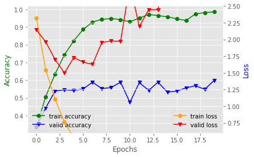

```python
batch_norm_network.plot_progress()
```

**Answer for Question 3.4**  
*The accuracy of this model using batch normalization is 0.58. Compare to the model using dropout, batch normalization has a slightly lower accuracy, but this model using batch normalization has a higher accuracy than the model not using it. In conclusion, it improves the model but not as much as dropout in my case. Overfitting exists in this model. Train loss is very low but validation loss is very high; train accuracy is very high but validation accuracy is lower (gap between validation accuracy and training accuracy very big).*

**Question 3.5** **We now try to apply data augmentation to improve the performance. Extend the code of the class `YourModel` so that if the attribute `is_augmentation` is set to `True`, we apply the data augmentation. Also we need to incorporate early stopping to your training process. Specifically, we can early stop the training if the valid accuracy cannot increase in three consecutive epochs.**

[4 points]

```python
from tensorflow.keras.preprocessing.image import ImageDataGenerator
```

Wtire your code in the cell below. Hint that you can rewrite the code of `fit` method to apply the data augmentation. In addition, you can copy the code of `build_cnn` method above to reuse here.

```python
class YourModel(DefaultModel):
    def __init__(self,
                 name='network1',
                 width=32, height=32, depth=3,
                 num_blocks=2,
                 feature_maps=32,
                 num_classes=4,
                 drop_rate=0.2,
                 batch_norm = None,
                 is_augmentation = False,
                 activation_func='relu',
                 optimizer='adam',
                 batch_size=10,
                 num_epochs= 20,
                 learning_rate=0.0001):
        super(YourModel, self).__init__(name, width, height, depth, num_blocks, feature_maps, num_classes, drop_rate,
                                        batch_norm, is_augmentation, activation_func, optimizer, batch_size, num_epochs,
                                        learning_rate)

    def build_cnn(self):
        self.model = models.Sequential()
        self.model.add(Conv2D(32, (3,3), padding='same', activation=self.activation_func, input_shape=(32,32,3)))
        self.model.add(Conv2D(32, (3,3), padding='same', activation=self.activation_func))
        self.model.add(MaxPooling2D(pool_size=(2, 2), padding='same'))
        if self.batch_norm is not None:
            self.model.add(BatchNormalization())
        self.model.add(Dropout(self.drop_rate))

        self.model.add(Conv2D(64, (3,3), padding='same', activation=self.activation_func))
        self.model.add(Conv2D(64, (3,3), padding='same', activation=self.activation_func))
        self.model.add(MaxPooling2D(pool_size=(2, 2), padding='same'))
        if self.batch_norm is not None:
            self.model.add(BatchNormalization())
        self.model.add(Dropout(self.drop_rate))

        self.model.add(Flatten())
        self.model.add(Dense(self.num_classes, activation='softmax'))
        self.model.compile(optimizer=self.optimizer, loss='sparse_categorical_crossentropy', metrics=['accuracy'])


    def fit(self, data_manager, batch_size=None, num_epochs=None):
        batch_size = self.batch_size if batch_size is None else batch_size
        num_epochs = self.num_epochs if num_epochs is None else num_epochs
        callback = tf.keras.callbacks.EarlyStopping(monitor='val_accuracy', patience=3)
        self.model.compile(optimizer=self.optimizer, loss='sparse_categorical_crossentropy', metrics=['accuracy'])
        if self.is_augmentation:
            datagen = ImageDataGenerator(horizontal_flip=True, shear_range=0.1)
            datagen.fit(data_manager.X_train)
            it = datagen.flow(data_manager.X_train, data_manager.y_train, batch_size=batch_size)
            self.history = self.model.fit(it, epochs=num_epochs, validation_data=(data_manager.X_valid, data_manager.y_valid),
                                          callbacks=[callback])
        else:
            self.history = self.model.fit(x = data_manager.X_train, y = data_manager.y_train,
                                          validation_data = (data_manager.X_valid, data_manager.y_valid),
                                          epochs = num_epochs, batch_size = batch_size, verbose= self.verbose,
                                          callbacks=[callback])
```

**Question 3.6** **Leverage the data augmentation with dropout and batch norm, and try to observe if you can really boost the performance.**

[4 points]

```python
no_aug_network = YourModel(name='network_no_aug',
                     feature_maps=32,
                     num_classes=len(data_manager.classes),
                     num_blocks=4,
                     drop_rate= 0.5,
                     batch_norm=True,
                     optimizer='adam',
                     is_augmentation = False,
                     learning_rate=0.001)
no_aug_network.build_cnn()
no_aug_network.fit(data_manager, num_epochs=20)
loss, acc = no_aug_network.model.evaluate(data_manager.X_test, data_manager.y_test)
print("\nAccuracy and loss of model using dropout, batch norm but no data augmentation are {} and {} respectively."
      .format(acc, loss))
```

```
Accuracy and loss of model using dropout, batch norm but no data augmentation are 0.6140000224113464 and 1.5594534873962402 respectively.
```

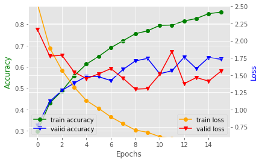

```python
# Plot progress of model without using data augmentation
no_aug_network.plot_progress()
```

```python
all_network = YourModel(name='network_all',
                     feature_maps=32,
                     num_classes=len(data_manager.classes),
                     num_blocks=4,
                     drop_rate= 0.5,
                     batch_norm=True,
                     optimizer='adam',
                     is_augmentation = True,
                     learning_rate=0.001)
all_network.build_cnn()
all_network.fit(data_manager, num_epochs=20)
loss, acc = all_network.model.evaluate(data_manager.X_test, data_manager.y_test)
print("\nAccuracy and loss of model using dropout, batch norm and data augmentation are {} and {} respectively."
      .format(acc, loss))
```

```
Accuracy and loss of model using dropout, batch norm and data augmentation are 0.6539999842643738 and 1.1100597381591797 respectively.
```

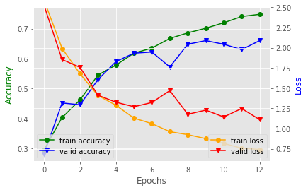

```python
# Plot progress of model using data augmentation
all_network.plot_progress()
```

**Answer for Question 3.6**  
*Comparing the training progress of model with no data augmentation and model with data augmentation above, we can clearly see that overfitting is reduced using model applying data augmentation because the difference between training accuracy and validation accuracy, and training loss and validation loss are both smaller compared to model without data augmentation. The performance is also better for model using data augmentation (accuracy: 0.65) compared to model without using data augmentation (accuracy: 0.61).*

**Question 3.7** **Exploring Label Smoothing Technique for Improving Generalization Ability.**

[4 points]

Label smoothing is a super-simple technique used to boost the generalization ability of deep learning models. You need to incoroporate label smoothing technique to the above deep learning model and experiment its performance. There are some papers and documents for label smoothing reference as follows:

- Main paper from Goeff Hinton [link for main paper](https://papers.nips.cc/paper/2019/file/f1748d6b0fd9d439f71450117eba2725-Paper.pdf) and a good article [article link](https://towardsdatascience.com/what-is-label-smoothing-108debd7ef06).

You need to extend your model developed above with label smoothing technique, train a model with that code, and write your observations and comments about the result.

```python
class YourModel(DefaultModel):
    def __init__(self,
                 name='network1',
                 width=32, height=32, depth=3,
                 num_blocks=2,
                 feature_maps=32,
                 num_classes=4,
                 drop_rate=0.2,
                 batch_norm = None,
                 is_augmentation = False,
                 activation_func='relu',
                 optimizer='adam',
                 batch_size=10,
                 num_epochs= 20,
                 learning_rate=0.0001):
        super(YourModel, self).__init__(name, width, height, depth, num_blocks, feature_maps, num_classes, drop_rate,
                                        batch_norm, is_augmentation, activation_func, optimizer, batch_size, num_epochs,
                                        learning_rate)

    def build_cnn(self):
        self.model = models.Sequential()
        self.model.add(Conv2D(32, (3,3), padding='same', activation=self.activation_func, input_shape=(32,32,3)))
        self.model.add(Conv2D(32, (3,3), padding='same', activation=self.activation_func))
        self.model.add(MaxPooling2D(pool_size=(2, 2), padding='same'))
        if self.batch_norm is not None:
            self.model.add(BatchNormalization())
        self.model.add(Dropout(self.drop_rate))

        self.model.add(Conv2D(64, (3,3), padding='same', activation=self.activation_func))
        self.model.add(Conv2D(64, (3,3), padding='same', activation=self.activation_func))
        self.model.add(MaxPooling2D(pool_size=(2, 2), padding='same'))
        if self.batch_norm is not None:
            self.model.add(BatchNormalization())
        self.model.add(Dropout(self.drop_rate))

        self.model.add(Flatten())
        self.model.add(Dense(self.num_classes, activation='softmax'))
        self.model.compile(optimizer=self.optimizer, loss=tf.keras.losses.CategoricalCrossentropy(label_smoothing=0.1),
                           metrics=['accuracy'])


    def fit(self, data_manager, batch_size=None, num_epochs=None):
        batch_size = self.batch_size if batch_size is None else batch_size
        num_epochs = self.num_epochs if num_epochs is None else num_epochs
        callback = tf.keras.callbacks.EarlyStopping(monitor='val_accuracy', patience=3)
        self.model.compile(optimizer=self.optimizer, loss=tf.keras.losses.CategoricalCrossentropy(label_smoothing=0.1),
                           metrics=['accuracy'])
        if self.is_augmentation:
            datagen = ImageDataGenerator(horizontal_flip=True, shear_range=0.1)
            datagen.fit(data_manager.X_train)
            y_train = tf.one_hot(data_manager.y_train, depth=self.num_classes)
            y_valid = tf.one_hot(data_manager.y_valid, depth=self.num_classes)
            it = datagen.flow(data_manager.X_train, y_train, batch_size=batch_size)
            self.history = self.model.fit(it, epochs=num_epochs, validation_data=(data_manager.X_valid, y_valid),
                                          callbacks=[callback])
        else:
            self.history = self.model.fit(x = data_manager.X_train, y = data_manager.y_train,
                                          validation_data = (data_manager.X_valid, data_manager.y_valid), epochs = num_epochs,
                                          batch_size = batch_size, verbose= self.verbose, callbacks=[callback])
```

```python
ls_network = YourModel(name='network_all',
                     feature_maps=32,
                     num_classes=len(data_manager.classes),
                     num_blocks=4,
                     drop_rate= 0.5,
                     batch_norm=True,
                     optimizer='adam',
                     is_augmentation = True,
                     learning_rate=0.001)
ls_network.build_cnn()
ls_network.fit(data_manager, num_epochs=20)
y_test = tf.one_hot(data_manager.y_test, depth=ls_network.num_classes)
loss, acc = ls_network.model.evaluate(data_manager.X_test, y_test)
print("\nAccuracy and loss of model using label smoothing are {} and {} respectively.".format(acc, loss))
```

```
Accuracy and loss of model using label smoothing are 0.6620000004768372 and 1.3138552904129028 respectively.
```

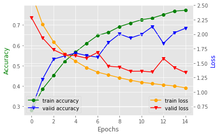

```python
# With label smoothing
ls_network.plot_progress()
```

**Question 3.8** **Exploring Data Mixup Technique for Improving Generalization Ability.**

[4 points]

Data mixup is another super-simple technique used to boost the generalization ability of deep learning models. You need to incoroporate data mixup technique to the above deep learning model and experiment its performance. There are some papers and documents for label smoothing reference as follows:

- Main paper for data mixup [link for main paper](https://openreview.net/pdf?id=r1Ddp1-Rb) and a good article [article link](https://www.inference.vc/mixup-data-dependent-data-augmentation/).

You need to extend your model developed above with label smoothing technique, train a model with that code, and write your observations and comments about the result.

```python
# You can download the file from this website: https://github.com/yu4u/mixup-generator
# Then import MixupGenerator from the file you downloaded

import numpy as np

class MixupGenerator():
    def __init__(self, X_train, y_train, batch_size=32, alpha=0.2, shuffle=True, datagen=None):
        self.X_train = X_train
        self.y_train = y_train
        self.batch_size = batch_size
        self.alpha = alpha
        self.shuffle = shuffle
        self.sample_num = len(X_train)
        self.datagen = datagen

    def __call__(self):
        while True:
            indexes = self.__get_exploration_order()
            itr_num = int(len(indexes) // (self.batch_size * 2))

            for i in range(itr_num):
                batch_ids = indexes[i * self.batch_size * 2:(i + 1) * self.batch_size * 2]
                X, y = self.__data_generation(batch_ids)

                yield X, y

    def __get_exploration_order(self):
        indexes = np.arange(self.sample_num)

        if self.shuffle:
            np.random.shuffle(indexes)

        return indexes

    def __data_generation(self, batch_ids):
        _, h, w, c = self.X_train.shape
        l = np.random.beta(self.alpha, self.alpha, self.batch_size)
        X_l = l.reshape(self.batch_size, 1, 1, 1)
        y_l = l.reshape(self.batch_size, 1)

        X1 = self.X_train[batch_ids[:self.batch_size]]
        X2 = self.X_train[batch_ids[self.batch_size:]]
        X = X1 * X_l + X2 * (1 - X_l)

        if self.datagen:
            for i in range(self.batch_size):
                X[i] = self.datagen.random_transform(X[i])
                X[i] = self.datagen.standardize(X[i])

        if isinstance(self.y_train, list):
            y = []

            for y_train_ in self.y_train:
                y1 = y_train_[batch_ids[:self.batch_size]]
                y2 = y_train_[batch_ids[self.batch_size:]]
                y.append(np.around(y1 * y_l + y2 * (1 - y_l)),decimals=5)
        else:
            y1 = self.y_train[batch_ids[:self.batch_size]]
            y2 = self.y_train[batch_ids[self.batch_size:]]
            y = np.around(y1 * y_l + y2 * (1 - y_l), decimals=5)

        return X, y
```

```python
import numpy as np

class YourModel(DefaultModel):
    def __init__(self,
                 name='network1',
                 width=32, height=32, depth=3,
                 num_blocks=2,
                 feature_maps=32,
                 num_classes=4,
                 drop_rate=0.2,
                 batch_norm = None,
                 is_augmentation = False,
                 activation_func='relu',
                 optimizer='adam',
                 batch_size=10,
                 num_epochs= 20,
                 learning_rate=0.0001):
        super(YourModel, self).__init__(name, width, height, depth, num_blocks, feature_maps, num_classes, drop_rate,
                                        batch_norm, is_augmentation, activation_func, optimizer, batch_size, num_epochs,
                                        learning_rate)

    def build_cnn(self):
        self.model = models.Sequential()
        self.model.add(Conv2D(32, (3,3), padding='same', activation=self.activation_func, input_shape=(32,32,3)))
        self.model.add(Conv2D(32, (3,3), padding='same', activation=self.activation_func))
        self.model.add(MaxPooling2D(pool_size=(2, 2), padding='same'))
        if self.batch_norm is not None:
            self.model.add(BatchNormalization())
        self.model.add(Dropout(self.drop_rate))

        self.model.add(Conv2D(64, (3,3), padding='same', activation=self.activation_func))
        self.model.add(Conv2D(64, (3,3), padding='same', activation=self.activation_func))
        self.model.add(MaxPooling2D(pool_size=(2, 2), padding='same'))
        if self.batch_norm is not None:
            self.model.add(BatchNormalization())
        self.model.add(Dropout(self.drop_rate))

        self.model.add(Flatten())
        self.model.add(Dense(self.num_classes, activation='softmax'))
        self.model.compile(optimizer=self.optimizer, loss=tf.keras.losses.CategoricalCrossentropy(label_smoothing=0.1),
                           metrics=['accuracy'])


    def fit(self, data_manager, batch_size=None, num_epochs=None):
        batch_size = self.batch_size if batch_size is None else batch_size
        num_epochs = self.num_epochs if num_epochs is None else num_epochs
        callback = tf.keras.callbacks.EarlyStopping(monitor='val_accuracy', patience=3)
        self.model.compile(optimizer=self.optimizer, loss=tf.keras.losses.CategoricalCrossentropy(label_smoothing=0.1),
                           metrics=['accuracy'])
        if self.is_augmentation:
            y_train = keras.utils.to_categorical(data_manager.y_train, self.num_classes)
            y_train = tf.one_hot(data_manager.y_train, depth=self.num_classes).numpy()
            y_valid = tf.one_hot(data_manager.y_valid, depth=self.num_classes).numpy()
            aug = ImageDataGenerator(horizontal_flip=True, shear_range=0.1)
            training_generator = MixupGenerator(data_manager.X_train, y_train, batch_size=batch_size, alpha=0.2, datagen=aug)()

            self.history = self.model.fit(training_generator, epochs=num_epochs, steps_per_epoch=400,
                                          validation_data=(data_manager.X_valid, y_valid), callbacks=[callback])
        else:
            self.history = self.model.fit(x = data_manager.X_train, y = data_manager.y_train,
                                          validation_data = (data_manager.X_valid, data_manager.y_valid),
                                          epochs = num_epochs, batch_size = batch_size, verbose= self.verbose,
                                          callbacks=[callback])

    def loss(self, y_true, y_pred):
        return tf.keras.losses.categorical_crossentropy(y_true, y_pred, label_smoothing = 0.2)
```

```python
mu_network = YourModel(name='network_mu',
                     feature_maps=32,
                     num_classes=len(data_manager.classes),
                     num_blocks=4,
                     drop_rate= 0.5,
                     batch_norm=True,
                     optimizer='adam',
                     is_augmentation = True,
                     learning_rate=0.001)
mu_network.build_cnn()
mu_network.fit(data_manager, num_epochs=20)
y_test = tf.one_hot(data_manager.y_test, depth=mu_network.num_classes)
loss, acc = mu_network.model.evaluate(data_manager.X_test, y_test)
print("\nAccuracy and loss of model using data mixup technique are {} and {} respectively.".format(acc, loss))
```

```
Accuracy and loss of model using data mixup technique are 0.6700000166893005 and 1.2760035991668701 respectively.
```

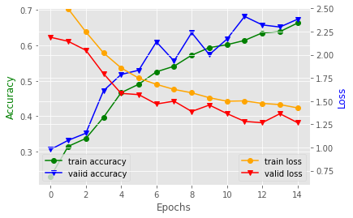

```python
mu_network.plot_progress()
```

**Question 3.9** **Attack your best obtained model with PGD, MIM, and FGSM attacks with $\epsilon= 0.0313, k=20, \eta= 0.005$ on the testing set. Write the code for the attacks and report the robust accuracies. Also choose a random set of 20 clean images in the testing set and visualize the original and attacked images.**

[4 points]

```python
def plot_image_grid(num_row, num_col, image, label, image_shape):
        fig, axes = plt.subplots(num_row, num_col, figsize=(1.5*num_col,2*num_row))
        for i in range(num_row*num_col):
            ax = axes[i//num_col, i%num_col]
            ax.grid(False)
            ax.imshow(image[i].reshape(image_shape), cmap='gray')
            ax.set_title('Label: {}'.format(label[i]))
        plt.tight_layout()
        plt.show()
```

PGD Attack:

```
Test adv accuracy: 0.104

Printing 20 clean random images from testing set
Original images:
```

[output not shown]

```
Attacked images:
```

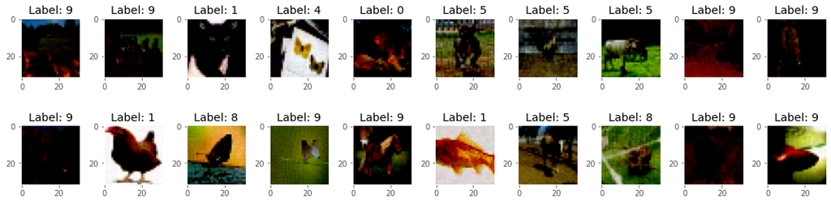

```python
def pgd_attack(model, input_image, input_label= None,
              epsilon=0.3,
              num_steps=20,
              step_size=0.01,
              clip_value_min=0.,
              clip_value_max=1.0,
              soft_label=False,
              from_logits= True):
    """
    Args:
        model: pretrained model
        input_image: original (clean) input image (tensor)
        input_label: original label (tensor, categorical representation)
        epsilon: perturbation boundary
        num_steps: number of attack steps
        step_size: size of each move in each attack step
        clip_value_min, clip_value_max: range of valid input
        from_logits = True: attack from logits otherwise attack from prediction probabilites
    Note:
        we expect the output of model should be logits vector
    """

    loss_fn = tf.keras.losses.sparse_categorical_crossentropy  #compute CE loss from logits or prediction probabilities

    if type(input_image) is np.ndarray:
        input_image = tf.convert_to_tensor(input_image)

    if type(input_label) is np.ndarray:
        input_label = tf.convert_to_tensor(input_label)

    # random initialization around input_image
    random_noise = tf.random.uniform(shape=input_image.shape, minval=-epsilon, maxval=epsilon)
    random_noise = tf.cast(random_noise, dtype=tf.float64)
    adv_image = input_image + random_noise

    for _ in range(num_steps):
        with tf.GradientTape(watch_accessed_variables=False) as tape:
            tape.watch(adv_image)
            adv_output = model(adv_image)
            if not soft_label:
                loss = loss_fn(input_label, adv_output, from_logits= from_logits) # use ground-truth label to attack
            else:
                pred_label = tf.math.argmax(adv_output, axis=1)
                loss = loss_fn(pred_label, adv_output, from_logits= from_logits) # use predicted label to attack

        gradient = tape.gradient(loss, adv_image) # get the gradient of the loss w.r.t. the current point
        adv_image = adv_image + step_size * tf.sign(gradient)
        adv_image = tf.clip_by_value(adv_image, input_image-epsilon, input_image+epsilon) # clip to a valid boundary
        adv_image = tf.clip_by_value(adv_image, clip_value_min, clip_value_max)  # clip to a valid range
        adv_image = tf.stop_gradient(adv_image) # stop the gradient to make the adversarial image as a constant input
    return adv_image


# Attack best obtained model with PGD attacks with 𝜖=0.0313, 𝑘=20, 𝜂=0.005 on the testing set.
y_adv = []
y_true = []
X_batch_adv = pgd_attack(model=mu_network.model, input_image=data_manager.X_test, input_label=data_manager.y_test,
                         epsilon=0.0313, num_steps=20, step_size=0.005, from_logits=False)
y_batch_adv = np.argmax(mu_network.model(X_batch_adv).numpy(), 1)
y_adv.append(y_batch_adv.tolist())
y_true.append(data_manager.y_test.tolist())


# Report robust accuracy
from sklearn.metrics import accuracy_score
test_adv_acc = accuracy_score(y_true[0], y_adv[0])
print("Test adv accuracy: {}".format(test_adv_acc))


# Choose a random set of 20 clean images in the testing set and visualize the original and attacked images
import random
random20 = []
for _ in range(20):
    random20.append(random.randrange(len(data_manager.X_test)-1))

image_samples_adv = pgd_attack(mu_network.model, data_manager.X_test[random20], data_manager.y_test[random20], epsilon=0.0313,
                               num_steps=20, step_size=0.005, from_logits=False)
label_sample_adv = np.argmax(mu_network.model(image_samples_adv).numpy(), 1)

print("\nPrinting 20 clean random images from testing set\nOriginal images:")
plot_image_grid(2, 10, data_manager.X_test[random20], data_manager.y_test[random20], (32,32,3))
print("Attacked images:")
plot_image_grid(2, 10, image_samples_adv.numpy(), label_sample_adv, (32,32,3))
```

MIM Attack:

```
Test adv accuracy: 0.106

Printing 20 clean random images from testing set
Original images:
```

[output not shown]

```
Attacked images:
```

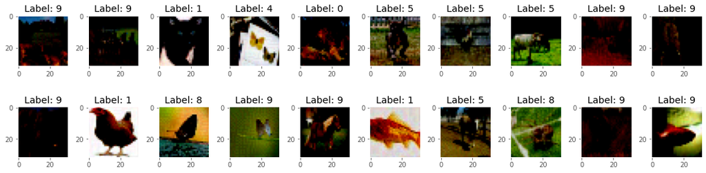

```python
def mim_attack(model, input_image, input_label= None,
              epsilon=0.3,
              gamma= 0.9,
              num_steps=20,
              step_size=0.01,
              clip_value_min=0.,
              clip_value_max=1.0,
              soft_label=False,
              from_logits= True):
    """
    Args:
        model: pretrained model
        input_image: original (clean) input image (tensor)
        input_label: original label (tensor, categorical representation)
        epsilon: perturbation boundary
        gamma: momentum decay
        num_steps: number of attack steps
        step_size: size of each move in each attack step
        clip_value_min, clip_value_max: range of valid input
        from_logits = True: attack from logits otherwise attack from prediction probabilites
    Note:
        we expect the output of model should be logits vector
    """

    loss_fn = tf.keras.losses.sparse_categorical_crossentropy # compute CE loss from logits or prediction probabilities

    if type(input_image) is np.ndarray:
        input_image = tf.convert_to_tensor(input_image)

    if type(input_label) is np.ndarray:
        input_label = tf.convert_to_tensor(input_label)

    # random initialization around input_image
    random_noise = tf.random.uniform(shape=input_image.shape, minval=-epsilon, maxval=epsilon)
    random_noise = tf.cast(random_noise, dtype=tf.float64)
    adv_image = input_image + random_noise
    adv_noise = random_noise

    for _ in range(num_steps):
        with tf.GradientTape(watch_accessed_variables=False) as tape:
            tape.watch(adv_image)
            adv_output = model(adv_image)
            if not soft_label:
                loss = loss_fn(input_label, adv_output, from_logits=from_logits) # use ground-truth label to attack
            else:
                pred_label = tf.math.argmax(adv_output, axis=1)
                loss = loss_fn(pred_label, adv_output, from_logits=from_logits) # use predicted label to attack

        gradient = tape.gradient(loss, adv_image) # get the gradient of the loss w.r.t. the current point
        adv_image_new = adv_image + step_size * tf.sign(gradient) # move current adverarial example along the gradient direction with step size is eta
        adv_image_new = tf.clip_by_value(adv_image_new, input_image-epsilon, input_image+epsilon) # clip to a valid boundary
        adv_image_new = tf.clip_by_value(adv_image_new, clip_value_min, clip_value_max) # clip to a valid range
        adv_noise = gamma*adv_noise + (1-gamma)*(adv_image_new - adv_image)
        adv_image = adv_image_new
        adv_image = tf.stop_gradient(adv_image) # stop the gradient to make the adversarial image as a constant input
    adv_image = adv_image + adv_noise
    adv_image = tf.clip_by_value(adv_image, input_image-epsilon, input_image+epsilon) # clip to a valid boundary
    adv_image = tf.clip_by_value(adv_image, clip_value_min, clip_value_max) # clip to a valid range
    return adv_image



# Attack best obtained model with MIM attacks with 𝜖=0.0313, 𝑘=20, 𝜂=0.005 on the testing set.
y_adv = []
y_true = []
X_batch_adv = mim_attack(model=mu_network.model, input_image=data_manager.X_test, input_label=data_manager.y_test,
                         epsilon=0.0313, num_steps=20, step_size=0.005, from_logits=False)
y_batch_adv = np.argmax(mu_network.model(X_batch_adv).numpy(), 1)
y_adv.append(y_batch_adv.tolist())
y_true.append(data_manager.y_test.tolist())


# Report robust accuracy
from sklearn.metrics import accuracy_score
test_adv_acc = accuracy_score(y_true[0], y_adv[0])
print("Test adv accuracy: {}".format(test_adv_acc))


# Choose a random set of 20 clean images in the testing set and visualize the original and attacked images
image_samples_adv = mim_attack(mu_network.model, data_manager.X_test[random20], data_manager.y_test[random20], epsilon=0.0313,
                               num_steps=20, step_size=0.005, from_logits=False)
label_sample_adv = np.argmax(mu_network.model(image_samples_adv).numpy(), 1)

print("\nPrinting 20 clean random images from testing set\nOriginal images:")
plot_image_grid(2, 10, data_manager.X_test[random20], data_manager.y_test[random20], (32,32,3))
print("Attacked images:")
plot_image_grid(2, 10, image_samples_adv.numpy(), label_sample_adv, (32,32,3))
```

FGSM Attack:

```
Test adv accuracy: 0.218

Printing 20 clean random images from testing set
Original images:
```

[output not shown]

```
Attacked images:
```

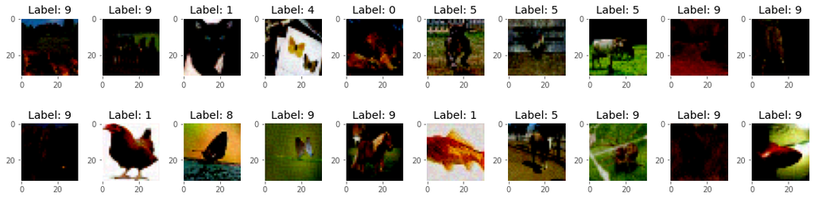

```python
def fgsm_attack(model, input_image, input_label=None,
               epsilon=0.3,
               clip_value_min=0.,
               clip_value_max=1.0,
               soft_label=False,
               from_logits=True):
    """
    Args:
        model: pretrained model
        input_image: original (clean) input image (tensor)
        input_label: original label (tensor, categorical representation)
        epsilon: perturbation boundary
        clip_value_min, clip_value_max: range of valid input
        from_logits = True: attack from logits otherwise attack from prediction probabilites
    Note:
        we expect the output of model should be logits vector
    """

    loss_fn = tf.keras.losses.sparse_categorical_crossentropy # compute CE loss from logits or prediction probabilities

    if type(input_image) is np.ndarray:
        input_image = tf.convert_to_tensor(input_image)

    if type(input_label) is np.ndarray:
        input_label = tf.convert_to_tensor(input_label)

    with tf.GradientTape() as tape:
        tape.watch(input_image)
        output = model(input_image)
        if not soft_label:
            loss = loss_fn(input_label, output, from_logits=from_logits) # use ground-truth label to attack
        else:
            pred_label = tf.math.argmax(output, axis=1) # use predicted label to attack
            loss = loss_fn(pred_label, output, from_logits=from_logits)

    gradient = tape.gradient(loss, input_image) # get the gradients of the loss w.r.t. the input image
    adv_image = input_image + epsilon * tf.sign(gradient) # get the final adversarial examples
    adv_image = tf.clip_by_value(adv_image, clip_value_min, clip_value_max) # clip to a valid range
    adv_image = tf.stop_gradient(adv_image) # stop the gradient to make the adversarial image as a constant input
    return adv_image



# Attack best obtained model with FGSM attacks with 𝜖=0.0313, 𝑘=20, 𝜂=0.005 on the testing set.
y_adv = []
y_true = []
X_batch_adv = fgsm_attack(mu_network.model, data_manager.X_test, data_manager.y_test, epsilon=0.0313, from_logits=False)
y_batch_adv = np.argmax(mu_network.model(X_batch_adv).numpy(), 1)
y_adv.append(y_batch_adv.tolist())
y_true.append(data_manager.y_test.tolist())


# Report robust accuracy
from sklearn.metrics import accuracy_score
test_adv_acc = accuracy_score(y_true[0], y_adv[0])
print("Test adv accuracy: {}".format(test_adv_acc))


# Choose a random set of 20 clean images in the testing set and visualize the original and attacked images
image_samples_adv = fgsm_attack(mu_network.model, data_manager.X_test[random20], data_manager.y_test[random20], epsilon=0.0313,
                                from_logits=False)
label_sample_adv = np.argmax(mu_network.model(image_samples_adv).numpy(), 1)

print("\nPrinting 20 clean random images from testing set\nOriginal images:")
plot_image_grid(2, 10, data_manager.X_test[random20], data_manager.y_test[random20], (32,32,3))
print("Attacked images:")
plot_image_grid(2, 10, image_samples_adv.numpy(), label_sample_adv, (32,32,3))
```

**Question 3.10** **Train a robust model using adversarial training with PGD ${\epsilon= 0.0313, k=10, \eta= 0.005}$. Write the code for the adversarial training and report the robust accuracies. After finishing the training, you need to store your best robust model in the folder `./models` and load the model to evaluate the robust accuracies for PGD, MIM, and FGSM attacks with $\epsilon= 0.0313, k=20, \eta= 0.005$ on the testing set.**

[4 points]

Train a robust model using adversarial training with PGD 𝜖=0.0313, 𝑘=10, 𝜂=0.005:

```python
mu_defence = mu_network.model

optimizer = tf.optimizers.Adam(learning_rate=0.001)
loss_obj = tf.nn.sparse_softmax_cross_entropy_with_logits

train_loss = tf.metrics.Mean(name='train_loss')
test_acc_clean = tf.metrics.SparseCategoricalAccuracy()
test_acc_pgd = tf.metrics.SparseCategoricalAccuracy()

def train_step_adv(x, x_adv, y):
    with tf.GradientTape() as tape:
        logits = mu_defence(x)
        logits_adv = mu_defence(x_adv)
        loss = (loss_obj(y, logits) + loss_obj(y, logits_adv))/2
        gradients = tape.gradient(loss, mu_defence.trainable_variables)
        optimizer.apply_gradients(zip(gradients, mu_defence.trainable_variables))
    return loss

epochs = 5
for epoch in range(epochs):
    progress_bar_train = tf.keras.utils.Progbar(4000)
    x_adv = pgd_attack(mu_defence, data_manager.X_train, data_manager.y_train, epsilon=0.0313, num_steps=10, step_size=0.005,
                       from_logits=False)
    loss = train_step_adv(data_manager.X_train, x_adv, data_manager.y_train)
    y_pred = mu_defence(data_manager.X_train)
    test_acc_clean(data_manager.y_train, y_pred)
    train_loss(loss)
    progress_bar_train.add(data_manager.X_train.shape[0], values=[('loss', train_loss.result()),
                                                                  ("acc (%)", test_acc_clean.result() * 100)])
```

Report the accuracy:

```python
y_adv = []
y_true = []
X_batch_adv = pgd_attack(model=mu_defence, input_image=data_manager.X_test, input_label=data_manager.y_test,
                         epsilon=0.0313, num_steps=10, step_size=0.005, from_logits=False)
y_batch_adv = np.argmax(mu_defence(X_batch_adv).numpy(), 1)
y_adv.append(y_batch_adv.tolist())
y_true.append(data_manager.y_test.tolist())

from sklearn.metrics import accuracy_score

test_adv_acc = accuracy_score(y_true[0], y_adv[0])
print("Test adv accuracy: {}".format(test_adv_acc))
```

```
Test adv accuracy: 0.208
```

Save the model:

```python
mu_defence.save('models/part3_q10_my_model')
```

Restore the model:

```python
model = tf.keras.models.load_model('models/part3_q10_my_model')
```

Evaluate the robust accuracies for PGD, MIM, and FGSM attacks with 𝜖=0.0313, 𝑘=20, 𝜂=0.005 on the testing set:  
PGD Attack:

```python
y_adv = []
y_true = []
X_batch_adv = pgd_attack(model=model, input_image=data_manager.X_test, input_label=data_manager.y_test,
                         epsilon=0.0313, num_steps=20, step_size=0.005, from_logits=False)
y_batch_adv = np.argmax(mu_defence(X_batch_adv).numpy(), 1)
y_adv.append(y_batch_adv.tolist())
y_true.append(data_manager.y_test.tolist())

from sklearn.metrics import accuracy_score

test_adv_acc = accuracy_score(y_true[0], y_adv[0])
print("Test adv accuracy: {}".format(test_adv_acc))
```

```
Test adv accuracy: 0.196
```

MIM Attack:

```python
y_adv = []
y_true = []
X_batch_adv = mim_attack(model=model, input_image=data_manager.X_test, input_label=data_manager.y_test,
                         epsilon=0.0313, num_steps=20, step_size=0.005, from_logits=False)
y_batch_adv = np.argmax(model(X_batch_adv).numpy(), 1)
y_adv.append(y_batch_adv.tolist())
y_true.append(data_manager.y_test.tolist())

from sklearn.metrics import accuracy_score

test_adv_acc = accuracy_score(y_true[0], y_adv[0])
print("Test adv accuracy: {}".format(test_adv_acc))
```

```
Test adv accuracy: 0.196
```

FGSM Attack:

```python
y_adv = []
y_true = []
X_batch_adv = fgsm_attack(model=model, input_image=data_manager.X_test, input_label=data_manager.y_test,
                          epsilon=0.0313, from_logits=False)
y_batch_adv = np.argmax(model(X_batch_adv).numpy(), 1)
y_adv.append(y_batch_adv.tolist())
y_true.append(data_manager.y_test.tolist())

from sklearn.metrics import accuracy_score

test_adv_acc = accuracy_score(y_true[0], y_adv[0])
print("Test adv accuracy: {}".format(test_adv_acc))
```

```
Test adv accuracy: 0.324
```